# Best of: Smammunity Analysis

Kate

November 10, 2018

#### 1. Shannon diversity

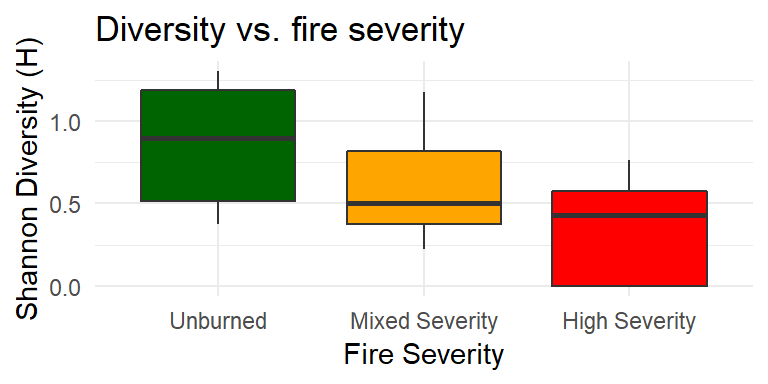

**Shannon diversity (H) decreased across the fire severity gradient.** Diversity differed significantly between the three fire severity treatments. Post-hoc analysis shows a significant difference between low and high severity means, but not between med vs. low or med vs. high severities.

- the data distribution is borderline funky and n is low (but at least the variance is comparable), so unsure about whether parametric tests are appropriate
- however, the results are the same using parametric tests (one-way ANOVA and Tukey’s HSD) and non-parametric tests (Kruskal-Wallis and Dunn’s test)

#### 2. Species richness

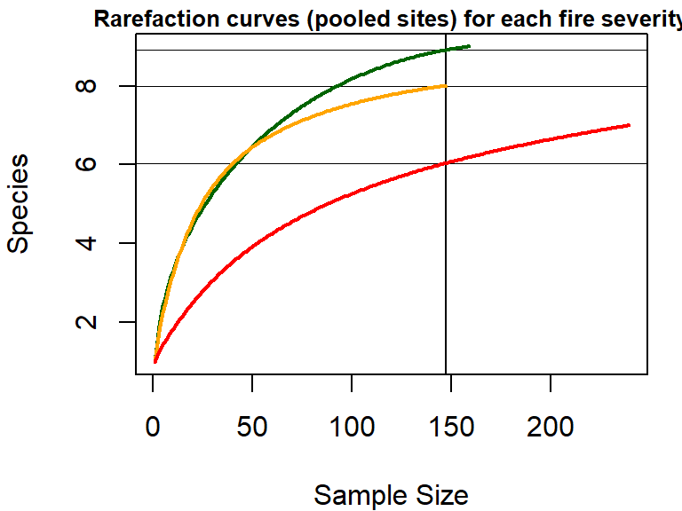

**Species richness decreased across the fire severity gradient.** Pooled rarefaction values, low to high severity are 8.9, 8.0, and 6.0 species.

I also tried rarefying per site, but the richness results were all between 1 and 3 species per site. Assuming this is bunk since the numbers are just too low. However, there were significant differences between the three severities, even though the numbers seemed funky.

#### 3. Overall small mammal abundance

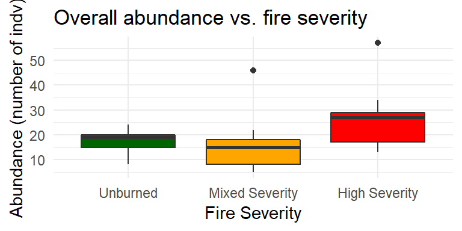

**The overall abundance of small mammals did not change with fire severity.** There was no significant difference in overall abundance in response to fire severity.

- results from nonparametric test (Kruskal-Wallis) because variance was all over the place

#### 4. PEMA abundance

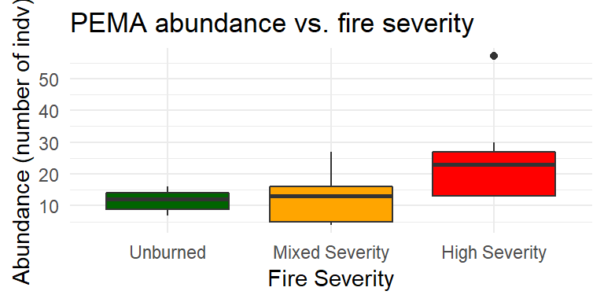

**PEMA abundance increased with fire severity.** Abundance in high severity was significantly different from both low and medium severities.

- results from nonparametric test (Kruskal-Wallis and Dunn’s test) because variance was all over the place

#### 5. PEMA proportion

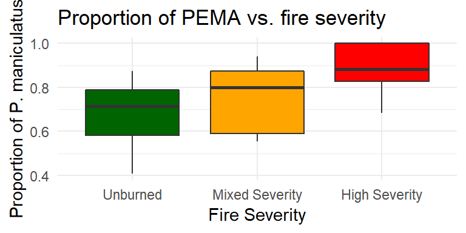

**The proportion of P. maniculatus increased with fire severity.** The mean proportion increased from 66.6% in unburned sites to 89.5% in high severity sites, with a significant difference between unburned and high severity, but not between low and med or med and high.

- Same results with parametric tests (ANOVA, Tukey’s HSD) and nonparametric tests (Kruskal-Wallis, Dunn’s test)

#### Concerns and future directions…

- Need to account for variable trapping effort
- Right now, diversity/richness/abundance estimates are based on numbers of unique individuals per species. Should I be worried about somehow accounting for animals that were caught multiple times versus animals that were only caught once? (*NOT a problem with density estimates via secr*)